# Predicting Stock Market Movements: How Hyperparameter Tuning Impacts LSTM Performance On Time-Series Tabular Data

1. Abstract
2. Learning objectives
3. Install the necessary dependencies
4. Import libraries and load the dataset
5. Inspect and plot the data
6. Preprocess data by splitting, normalising, and structuring into a sequence
7. Define hyperparameters
8. Define the (LSTM) network
9. Train the network
10. References
11. Evaluation

### Abstract:

Financial forecasting remains challenging due to the volatile nature of the stock market. This tutorial demonstrates a machine learning pipeline using a PyTorch Long Short-Term Memory (LSTM) neural network to predict the S&P500 stock closing price. This problem uses tabular time-series data as the dataset, which makes an ideal case for this network. This tutorial will demonstrate how adjusting hyperparameters (in this tutorial, learning rate and hidden dimensions) affects predictive performance using Mean Squared Error as a metric. We can visualise performance using tables and graphs. Users can easily adjust hyperparameters and the chosen dataset.

After following this tutorial you will achieve the following learning objectives:

- Preprocess time-series data suitable for a recurrent neural network.
- Construct and Train an LSTM neural network using PyTorch libraries, utilising a GPU if possible.
- Experiment with hyperparameters, especially learning rate, to optimise model performance.
- Evaluate and visualise the impact of different configurations using Matplotlib.

### Existing Tutorials

While many online resources cover stock prediction, they often lack a critical analysis of model tuning and present unrealistic results.

- **"Jupyter Notebook Complete Beginner Guide - From Jupyter to Jupyterlab, Google Colab and Kaggle!" https://www.youtube.com/watch?v=5pf0_bpNbkw**
  - Pros: Helpful tutorial for someone who has not used notebook before.
  - Cons: No help for building machine learning pipelines.
- **"Stock Prediction PyTorch" https://github.com/RodolfoLSS/stock-prediction-pytorch.git**
  - Pros: A fully functional, modular codebase for an LSTM, which separates code into separate cells. Uses graphs to display data.
  - Cons: Not much markdown explanations compared to other tutorials and so can be confusing to follow.
- **"Time Series Forecasting using Pytorch" https://www.geeksforgeeks.org/data-analysis/time-series-forecasting-using-pytorch/**
  - Pros: Provides step-by-step instructions in building machine learning models.
  - Cons: Does not use different hyperparameter configurations.
- **"Hyperparameter tuning using Ray Tune" https://docs.pytorch.org/tutorials/beginner/hyperparameter_tuning_tutorial.html**
  - Pros: An official resource so code quality is high and uses concepts like an adapting learning rate.
  - Cons: Complex and focuses on image classification using CNNs rather than time-series tabular data and LSTMs.

### Step 1: Install the necessary dependencies

To start, the following dependencies must be installed. In this code, we have used Yahoo Finance to get the market dataset. You can also see the other libraries to install

`pip install numpy pandas matplotlib scikit-learn yfinance`

And the following line is specific to my NVIDIA 3060 Mobile GPU to reduce training times

`pip install torch torchvision --index-url https://download.pytorch.org/whl/cu128`

For general use and training with your own CPU, the following pip install will be used

`pip install torch`

### Step 2 (Optional): Connect to the GPU or use CPU as processor

This step is optional but can lead to a noticeable performance increase and a decrease in waiting times for training. The tutorial is still usable on the regular version of torch and using your CPU for training.

```python
import torch
#Check if CUDA is available
device = torch.device("cuda" if torch.cuda.is_available() else "cpu")
print(f"Using device: {device}")
```

```
Using device: cuda
```

### Step 3: Import libraries and load the dataset

This step involves importing the various libraries ranging from numpy and sklearn to help with data processing to matplotlib for visualisation. The S&P500 dataset is also downloaded for a 5 year stretch from Yahoo Finance. We use the closing prices for every market day. You can replace the ticker for any stock you would like and tun the rest of the pipeline as necessary to test performance for other datasets.

```python
#Setup
import torch.nn as nn
from torch.utils.data import DataLoader, TensorDataset
import numpy as np
import pandas as pd
import matplotlib.pyplot as plt
import yfinance as yf
from sklearn.preprocessing import MinMaxScaler
import time

#Set random seeds for reproducibility for PyTorch and NumPy
torch.manual_seed(42)
np.random.seed(42)

#Download S&P500 Data from start of 2021 to March 2026. This can be changed to other names.
ticker = "^SPX"
data = yf.download(ticker, start="2021-01-01", end="2026-03-01")

#Keep only the 'Close' price column and drop NaNs
df = data[['Close']].dropna()
#Get year-end closing prices
year_end_prices = df['Close'].resample('YE').last()
```

```
[*********************100%***********************]  1 of 1 completed
```

### Step 4: Inspect and plot the data

We can understand the contents of the data from the table and graph. We are also able to see the variability in closing prices in the graph, which can indicate the need for a machine learning algorithm for prediction. This is a good visualisation to see the trends in the data. There is a general upwards trend year by year except for from the start and end of 2022.

```
   Year  Year-End Closing Price (USD)
0  2021                   4766.180176
1  2022                   3839.500000
2  2023                   4769.830078
3  2024                   5881.629883
4  2025                   6845.500000
5  2026                   6878.879883
```

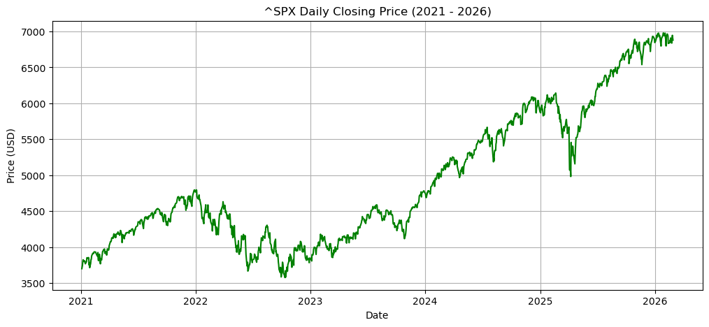

```python
#Visualise the raw dataset with a table of the year and the closing price
year_end_table = year_end_prices.reset_index()
year_end_table.columns = ['Year', 'Year-End Closing Price (USD)']
#Format the 'Year' column to show the year rather than YYYY-MM-DD
year_end_table['Year'] = year_end_table['Year'].dt.year
year_end_table = year_end_table[(year_end_table['Year'] >= 2021)]
print(year_end_table)

#Plot the closing price against the date for the whole dataset
plt.figure(figsize=(12, 5))
plt.plot(df.index, df['Close'], color='green')
plt.title(f"{ticker} Daily Closing Price (2021 - 2026)")
plt.xlabel("Date")
plt.ylabel("Price (USD)")
plt.grid(True)
plt.show()
```

### Step 5: Preprocess data

This step involves normalising the data using `MinMaxScaler` to scale the data from -1 to 1, helping the neural network converge faster. A sliding window of 30 days is used so the LSTM can see the last 30 days. The data is then split into 80% training and 20% for testing. Finally, the data in converted into PyTorch tensors. There are 1010 sequences to train on and 253 to test it on. This does not match up exactly with 365 days in a year because not every day is a trading day. The sequence size of 30 is seen, meaning 30 consecutive days are used to predict the next day. 1 indicates the amount of data recorded per day, and because we are only recording the closing price, this is the only feature.

```python
#Scale the data to the range -1 and 1
scaler = MinMaxScaler(feature_range=(-1, 1))
scaled_data = scaler.fit_transform(df['Close'].values.reshape(-1,1))

###This code is adapted from the sequence generation function from the GeeksforGeeks (2023) tutorial

#Create sequences of data for time series (Sliding Window)
def create_sequences(data, seq_length):
    xs, ys = [], []
    for i in range(len(data)-seq_length-1):
        x = data[i:(i+seq_length)]
        y = data[i+seq_length]
        xs.append(x)
        ys.append(y)
    return np.array(xs), np.array(ys)

seq_length = 30 #Look back 30 days
X, y = create_sequences(scaled_data, seq_length)

###End of source GeeksforGeeks (2023)
#Source: GeeksforGeeks (2023). Time Series Forecasting using Pytorch. [online] GeeksforGeeks. Available at: https://www.geeksforgeeks.org/data-analysis/time-series-forecasting-using-pytorch/.

#Split into training (80%) and testing (20%)
train_size = int(len(X) * 0.8)
X_train, y_train = X[:train_size], y[:train_size]
X_test, y_test = X[train_size:], y[train_size:]

#Convert to PyTorch Tensors which can be trained on the GPU
X_train = torch.from_numpy(X_train).float().to(device)
y_train = torch.from_numpy(y_train).float().to(device)
X_test = torch.from_numpy(X_test).float().to(device)
y_test = torch.from_numpy(y_test).float().to(device)

print(f"Training Data Shape: {X_train.shape}")
print(f"Testing Data Shape: {X_test.shape}")
```

```
Training Data Shape: torch.Size([1010, 30, 1])
Testing Data Shape: torch.Size([253, 30, 1])
```

### Step 6: Define hyperparameters

This step consists of defining the hyperparameters.

```python
#Architectural hyperparameters
input_dim=1
hidden_dim_A=32
hidden_dim_B=32
hidden_dim_C=32
hidden_dim_D = 16
hidden_dim_E = 64
num_layers=1
output_dim=1
dropout=0.2

#Training hyperparameters
epochs_A=200
lr_A=0.1
epochs_B=200
lr_B=0.15
epochs_C=200
lr_C=0.05
epochs_D = 200
lr_D = 0.1
epochs_E = 200
lr_E = 0.1
```

### Step 7: Define the (LSTM) network

The LSTM model is defined and can be found on GitHub.

```python
#LSTM code from source RodolfoLSS (2025)
class LSTM(nn.Module):
    def __init__(self, input_dim, hidden_dim, num_layers, output_dim, dropout):
        super(LSTM, self).__init__()
        self.hidden_dim = hidden_dim
        self.num_layers = num_layers

        #LSTM Layer
        self.lstm = nn.LSTM(input_dim, hidden_dim, num_layers, batch_first=True)
        #Fully Connected Layer for output
        self.fc = nn.Linear(hidden_dim, output_dim)

    def forward(self, x):
        #Initialise hidden and cell states
        h0 = torch.zeros(self.num_layers, x.size(0), self.hidden_dim).to(x.device).requires_grad_()
        c0 = torch.zeros(self.num_layers, x.size(0), self.hidden_dim).to(x.device).requires_grad_()
        #Forward propagate LSTM
        out, (hn, cn) = self.lstm(x, (h0.detach(), c0.detach()))
        #Decode the hidden state of the last time step
        out = self.fc(out[:, -1, :])
        return out

###End of source RodolfoLSS (2025)
#Source: RodolfoLSS (2025). stock-prediction-pytorch/stock-prediction-pytorch.ipynb at master · RodolfoLSS/stock-prediction-pytorch. [online] GitHub. Available at: https://github.com/RodolfoLSS/stock-prediction-pytorch/blob/master/stock-prediction-pytorch.ipynb.
```

### Step 8: Train the network

```python
def train_model(model, lr, epochs):
    criterion = nn.MSELoss()
    optimiser = torch.optim.Adam(model.parameters(), lr=lr)
    train_losses = []
    start_time = time.time()

    for epoch in range(epochs):
        model.train()
        optimiser.zero_grad()

        #Forward pass
        y_pred = model(X_train)
        loss = criterion(y_pred, y_train)

        #Backward pass and optimise
        loss.backward()
        optimiser.step()
        train_losses.append(loss.item())

    duration = time.time() - start_time

    #Calculate Test Loss
    model.eval()
    with torch.no_grad():
        test_pred = model(X_test)
        test_loss = criterion(test_pred, y_test).item()
    return model, train_losses, test_loss, duration, test_pred

print("Training Config A")
model_A = LSTM(input_dim, hidden_dim_A, num_layers, output_dim, dropout).to(device)
_, losses_A, test_loss_A, time_A, pred_A = train_model(model_A, lr=lr_A, epochs=epochs_A)

print("Training Config B")
model_B = LSTM(input_dim, hidden_dim_B, num_layers, output_dim, dropout).to(device)
_, losses_B, test_loss_B, time_B, pred_B = train_model(model_B, lr=lr_B, epochs=epochs_B)

print("Training Config C")
model_C = LSTM(input_dim, hidden_dim_C, num_layers, output_dim, dropout).to(device)
_, losses_C, test_loss_C, time_C, pred_C = train_model(model_C, lr=lr_C, epochs=epochs_C)

print("Training Config D")
model_D = LSTM(input_dim, hidden_dim_D, num_layers, output_dim, dropout).to(device)
_, losses_D, test_loss_D, time_D, pred_D = train_model(model_D, lr=lr_D, epochs=epochs_D)

print("Training Config E")
model_E = LSTM(input_dim, hidden_dim_E, num_layers, output_dim, dropout).to(device)
_, losses_E, test_loss_E, time_E, pred_E = train_model(model_E, lr=lr_E, epochs=epochs_E)

print("Done")
```

```
Training Config A
Training Config B
Training Config C
Training Config D
Training Config E
Done
```

### Step 9: Display results

Now you can see how the learning rate affects the performance. An MSE curve is used to see how it slowly converges, then a table of the hyperparameters (which are recommended to be fiddled with) and the resulting MSE and training times.

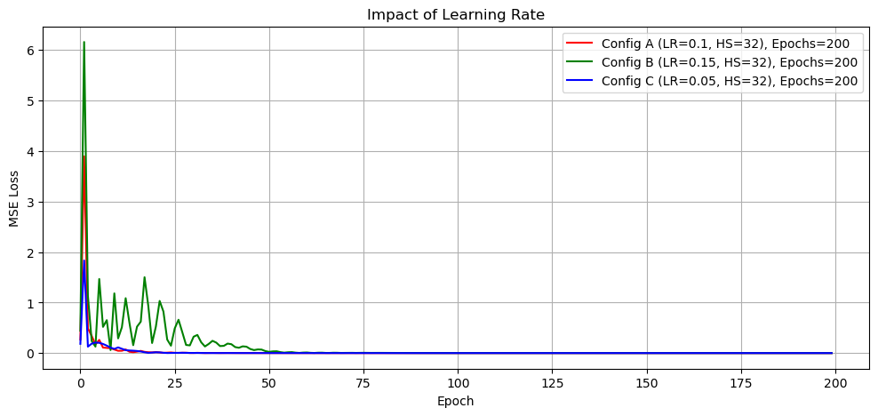

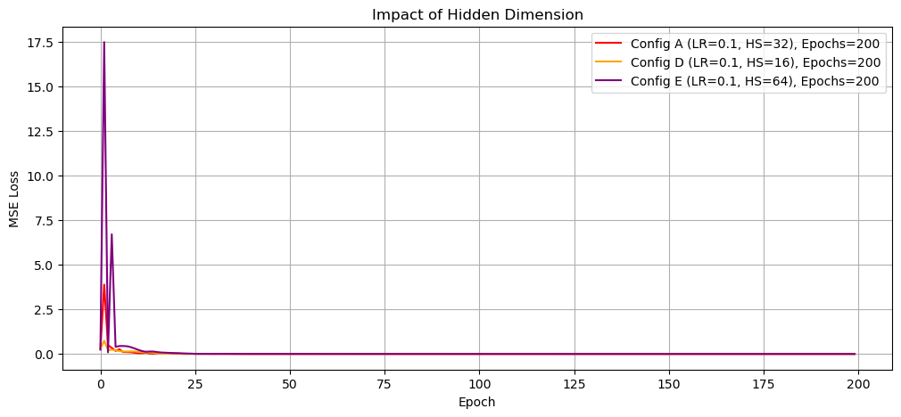

|  | Model Name | Epochs | Learning Rate | Hidden Size | Training Time (s) | Test Loss (MSE) |
| --- | --- | --- | --- | --- | --- | --- |
| 0 | Config A (Baseline) | 200 | 0.10 | 32 | 1.34 | 0.00822 |
| 1 | Config B (LR) | 200 | 0.15 | 32 | 0.93 | 0.02768 |
| 2 | Config C (LR) | 200 | 0.05 | 32 | 1.13 | 0.01259 |
| 3 | Config D (HS) | 200 | 0.10 | 16 | 0.98 | 0.01867 |
| 4 | Config E (HS) | 200 | 0.10 | 64 | 1.17 | 0.00467 |

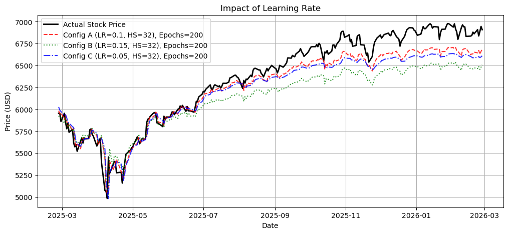

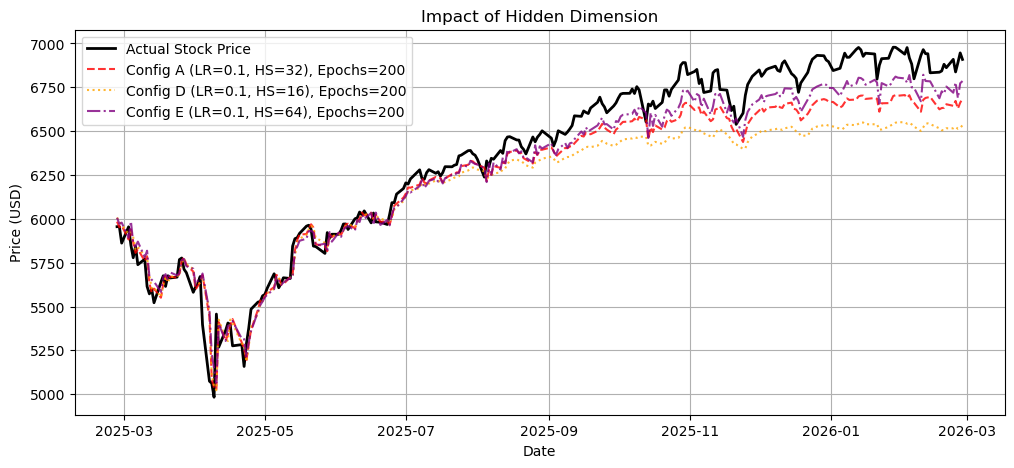

```python
#Plotting effect of learning rate
plt.figure(figsize=(12, 5))
plt.plot(losses_A, label=f"Config A (LR={lr_A}, HS={hidden_dim_A}), Epochs={epochs_A}", color='red')
plt.plot(losses_B, label=f"Config B (LR={lr_B}, HS={hidden_dim_B}), Epochs={epochs_B}", color='green')
plt.plot(losses_C, label=f"Config C (LR={lr_C}, HS={hidden_dim_C}), Epochs={epochs_C}", color='blue')
plt.title("Impact of Learning Rate")
plt.xlabel("Epoch")
plt.ylabel("MSE Loss")
plt.legend()
plt.grid(True)
plt.show()

#Plotting effect of hidden dimension
plt.figure(figsize=(12, 5))
plt.plot(losses_A, label=f"Config A (LR={lr_A}, HS={hidden_dim_A}), Epochs={epochs_A}", color='red')
plt.plot(losses_D, label=f"Config D (LR={lr_D}, HS={hidden_dim_D}), Epochs={epochs_D}", color='orange')
plt.plot(losses_E, label=f"Config E (LR={lr_E}, HS={hidden_dim_E}), Epochs={epochs_E}", color='purple')
plt.title("Impact of Hidden Dimension")
plt.xlabel("Epoch")
plt.ylabel("MSE Loss")
plt.legend()
plt.grid(True)
plt.show()

#Results table
results_df = pd.DataFrame({
    'Model Name': ['Config A (Baseline)', 'Config B (LR)', 'Config C (LR)', 'Config D (HS)', 'Config E (HS)'],
    'Epochs': [epochs_A, epochs_B, epochs_C, epochs_D, epochs_E],
    'Learning Rate': [lr_A, lr_B, lr_C, lr_D, lr_E],
    'Hidden Size': [hidden_dim_A, hidden_dim_B, hidden_dim_C, hidden_dim_D, hidden_dim_E],
    'Training Time (s)': [round(time_A, 2), round(time_B, 2), round(time_C, 2), round(time_D, 2), round(time_E, 2)],
    'Test Loss (MSE)': [round(test_loss_A, 5), round(test_loss_B, 5), round(test_loss_C, 5), round(test_loss_D, 5), round(test_loss_E, 5)]
})
display(results_df)

#Tensors must be moved back to the CPU before they can be converted to NumPy arrays
actual_prices = scaler.inverse_transform(y_test.cpu().numpy().reshape(-1, 1))

#Inverse transform the predictions for all configurations
predicted_prices_A = scaler.inverse_transform(pred_A.cpu().numpy().reshape(-1, 1))
predicted_prices_B = scaler.inverse_transform(pred_B.cpu().numpy().reshape(-1, 1))
predicted_prices_C = scaler.inverse_transform(pred_C.cpu().numpy().reshape(-1, 1))
predicted_prices_D = scaler.inverse_transform(pred_D.cpu().numpy().reshape(-1, 1))
predicted_prices_E = scaler.inverse_transform(pred_E.cpu().numpy().reshape(-1, 1))


#Take the dates from the end of the original dataframe
test_dates = df.index[-len(actual_prices):]
#Predictions based on learning rate
plt.figure(figsize=(12, 5))
plt.plot(test_dates, actual_prices, label='Actual Stock Price', color='black', linewidth=2)
plt.plot(test_dates, predicted_prices_A, label=f"Config A (LR={lr_A}, HS={hidden_dim_A}), Epochs={epochs_A}", color='red', linestyle='dashed', alpha=0.8)
plt.plot(test_dates, predicted_prices_B, label=f"Config B (LR={lr_B}, HS={hidden_dim_B}), Epochs={epochs_B}", color='green', linestyle='dotted', alpha=0.8)
plt.plot(test_dates, predicted_prices_C, label=f"Config C (LR={lr_C}, HS={hidden_dim_C}), Epochs={epochs_C}", color='blue', linestyle='dashdot', alpha=0.8)
plt.title("Impact of Learning Rate")
plt.xlabel("Date")
plt.ylabel("Price (USD)")
plt.legend()
plt.grid(True)
plt.show()

#Predictions based on hidden dimension
plt.figure(figsize=(12, 5))
plt.plot(test_dates, actual_prices, label='Actual Stock Price', color='black', linewidth=2)
plt.plot(test_dates, predicted_prices_A, label=f"Config A (LR={lr_A}, HS={hidden_dim_A}), Epochs={epochs_A}", color='red', linestyle='dashed', alpha=0.8)
plt.plot(test_dates, predicted_prices_D, label=f"Config D (LR={lr_D}, HS={hidden_dim_D}), Epochs={epochs_D}", color='orange', linestyle='dotted', alpha=0.8)
plt.plot(test_dates, predicted_prices_E, label=f"Config E (LR={lr_E}, HS={hidden_dim_E}), Epochs={epochs_E}", color='purple', linestyle='dashdot', alpha=0.8)
plt.title("Impact of Hidden Dimension")
plt.xlabel("Date")
plt.ylabel("Price (USD)")
plt.legend()
plt.grid(True)
plt.show()
```

### Step 10: Evaluation

From the training loss curves, we can observe how the learning rate affects the behaviour during gradient descent.

The final test loss curves also help our understanding.

- Config A has the lowest MSE
- Config B has a worse MSE, showing that the large learning rate has prevented it from finding the most optimal weights because of the large jumps
- Config C shows a smooth convergence but the learning rate is too small, meaning that it was stuck in a sub optimal local minimum compared to Config A.

For the hidden dimension curves, we can also interpret the behaviour.

- The lower capacity model performs worse than the baseline because the model does not have enough parameters to learn the complex movement of the stock market.
- The higher capacity model actually outperforms the baseline because of the increased model capacity, causing it to achieve the lowest Test MSE.

The predictive curve shows how the different models really perform on the test set. You can see how much each one varies from the actual results. The closest one being Config E. But each model roughly predicts peaks and drops well enough, following a similar enough pattern. Generally, the models understimate the magnitude of growth.

Now, you shall have successfully demonstrated a machine learning pipeline for time series forecasting using PyTorch.

## References

GeeksforGeeks (2023). Time Series Forecasting using Pytorch. [online] GeeksforGeeks. Available at: https://www.geeksforgeeks.org/data-analysis/time-series-forecasting-using-pytorch/.

Pytorch.org. (2024). Hyperparameter tuning with Ray Tune — PyTorch Tutorials 2.7.0+cu126 documentation. [online] Available at: https://docs.pytorch.org/tutorials/beginner/hyperparameter_tuning_tutorial.html.

RodolfoLSS (2025). stock-prediction-pytorch/stock-prediction-pytorch.ipynb at master · RodolfoLSS/stock-prediction-pytorch. [online] GitHub. Available at: https://github.com/RodolfoLSS/stock-prediction-pytorch/blob/master/stock-prediction-pytorch.ipynb.

Youtu.be. (2026). Available at: https://youtu.be/5pf0_bpNbkw?si=VXvEhov4giDr9mWL [Accessed 6 Mar. 2026].